# Problem Set 2

Author

Sabrina Zhang

Published

October 15, 2026

## 1. Data

The data set for this project is pulling from is the Federal Reserve Economic Database (FRED). This set will contain the Unemployment Rate in the US (overall), Oregon, California, Texas, and New York.

Series ID: `(UNRATE, ORUR, CAUR, TXUR, NYUR)`.

For this data set, the columns contains the date, unemployment rate, region, and the change in unemployment rate.

Each row represents a entry in the data set for the unemployment data reported for each month of each region. The symbol `UNRATE` represents the overall data for the United States.

Unemployment Rate: Raw Data

| symbol | date | unemployment_rate | region | unemployment_rate_change |
| --- | --- | --- | --- | --- |
| CAUR | 1976-01-01 | 9.2 | California | NA |
| CAUR | 1976-02-01 | 9.2 | California | 0.0 |
| CAUR | 1976-03-01 | 9.1 | California | -0.1 |
| CAUR | 1976-04-01 | 9.0 | California | -0.1 |
| CAUR | 1976-05-01 | 8.9 | California | -0.1 |
| CAUR | 1976-06-01 | 8.9 | California | 0.0 |

## 2. Wrangling

##### Data Set Summary

Unemployment Rate Summary

| region | mean_rate | min_rate | max_rate |
| --- | --- | --- | --- |
| California | 7.074342 | 3.8 | 16.1 |
| New York | 6.346546 | 3.8 | 16.7 |
| Oregon | 6.661513 | 3.4 | 13.7 |
| Texas | 5.847040 | 3.4 | 12.8 |
| United States | 6.046305 | 3.4 | 14.8 |

Summary of Unemployment Rate Since 2015

| region | mean_rate | min_rate | max_rate |
| --- | --- | --- | --- |
| California | 5.631429 | 3.8 | 16.1 |
| New York | 5.100714 | 3.8 | 16.7 |
| Oregon | 4.749286 | 3.4 | 13.7 |
| Texas | 4.581429 | 3.4 | 12.8 |
| United States | 4.619858 | 3.4 | 14.8 |

##### Top Unemployment Rate

Top 5 highest change in unemployment rate by increases or decreases, including when there are several data points where more than one unemployment rate change is the same.

Top Unemployment Increases Before COVID

| symbol | date | unemployment_rate | region | unemployment_rate_change |
| --- | --- | --- | --- | --- |
| TXUR | 2009-05-01 | 7.6 | Texas | 1.1 |
| ORUR | 2008-12-01 | 8.9 | Oregon | 0.7 |
| ORUR | 2008-11-01 | 8.2 | Oregon | 0.7 |
| ORUR | 2009-01-01 | 9.6 | Oregon | 0.7 |
| ORUR | 1980-03-01 | 7.4 | Oregon | 0.6 |
| UNRATE | 1980-04-01 | 6.9 | United States | 0.6 |

| symbol | date | unemployment_rate | region | unemployment_rate_change |
| --- | --- | --- | --- | --- |
| UNRATE | 1983-07-01 | 9.4 | United States | -0.7 |
| NYUR | 2021-09-01 | 6.2 | New York | -0.6 |
| ORUR | 1977-05-01 | 7.8 | Oregon | -0.5 |
| CAUR | 2021-07-01 | 7.4 | California | -0.5 |
| CAUR | 2021-09-01 | 6.5 | California | -0.5 |
| NYUR | 2021-07-01 | 7.0 | New York | -0.5 |
| UNRATE | 2010-12-01 | 9.3 | United States | -0.5 |
| UNRATE | 2014-04-01 | 6.2 | United States | -0.5 |
| UNRATE | 2021-07-01 | 5.4 | United States | -0.5 |

## 3. Data Visualization

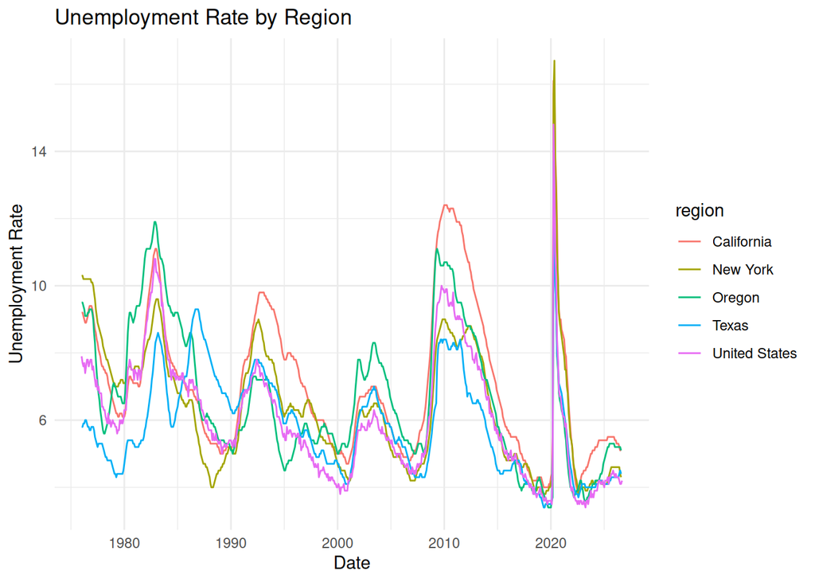

2. Unemployment Rate by region

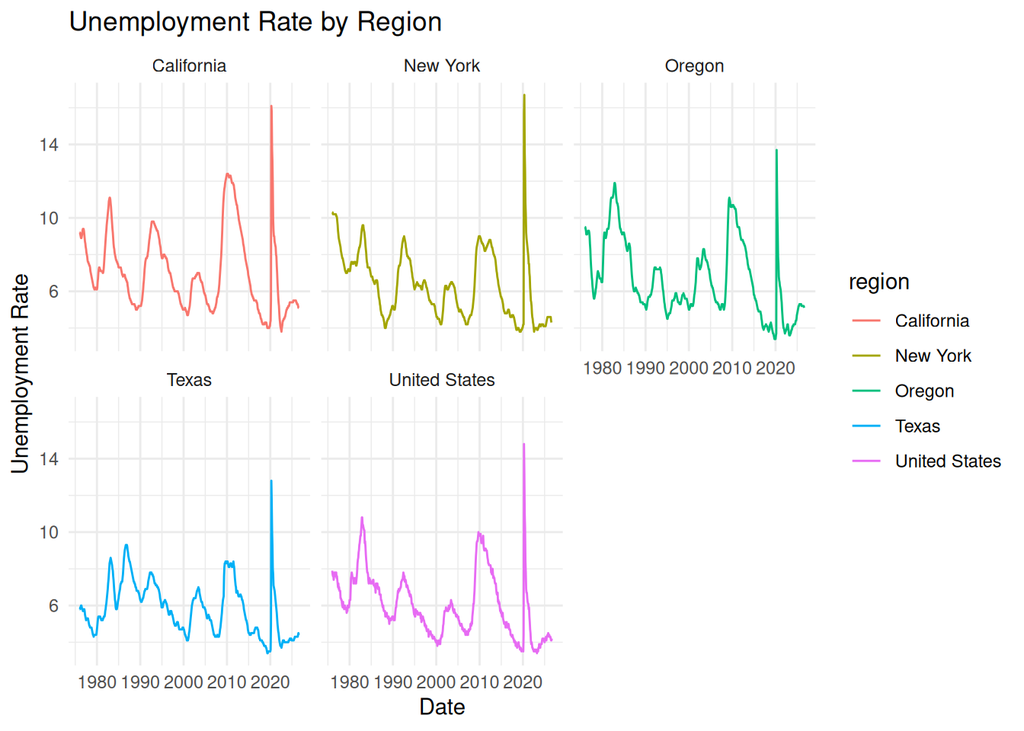

3. Average Unemployment Rate ranked from lowest to highest by region

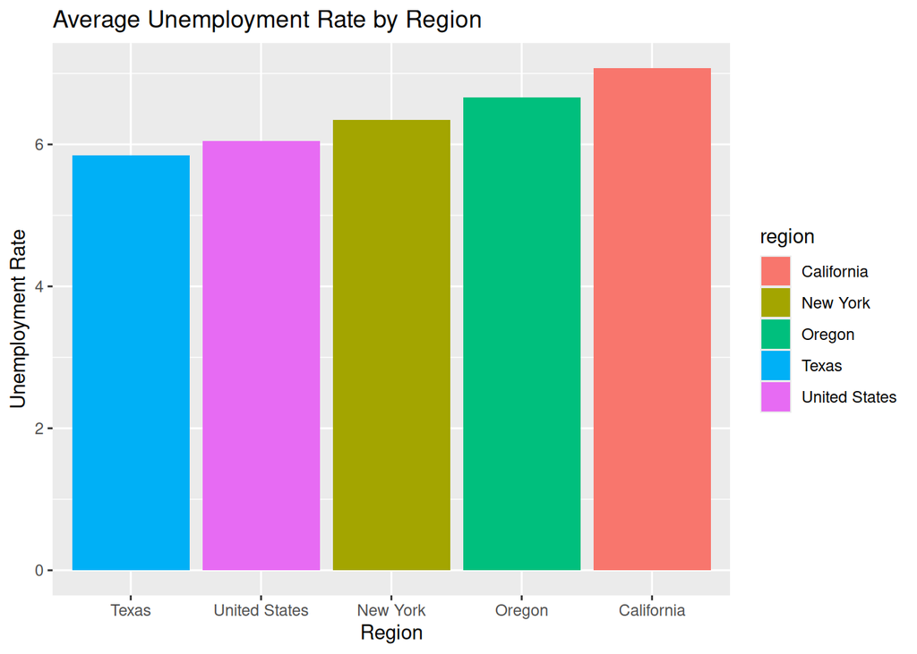

This is the unemployment data from Jan 2022 to present, representing the unemployment coming out of COVID, and the rise of the AI boom. What’s interesting about this data is the high unemployment rate in California, as casual inference can be made in regard to the highly concentrated tech sector.

Texas and New York see a similar rise in unemployment relative to the US as a whole.

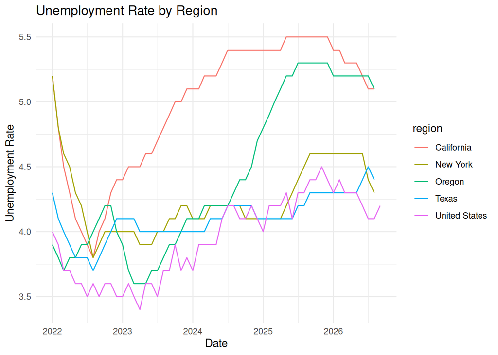